# Case Study 1_Solution

[figure not shown]

## Exercise Description

### The Heliotronics Case Data on Manufacturing Cost

Mr Clayton Handleman is the CEO of Heliotronics. He is very interested in this substantial contract from Switzerland and wonders about a competitive price for the bid. Mr Handleman discusses the bid with the company’s production director. Due to the substantial time lag between bid and offer it is not an easy task to determine a price for the bid. Especially since prices have decreased substantially over time in the past. The company’s production director estimates that by the time that Heliotronics will start producing the 400 solar panels for the canton Tessin in the second quarter of 2022 an additional 2400 solar panels will have been produced. Thus, the total production volume will be 4600 Units when the company starts to produce for the canton of Tessin. The estimate is too a large degree based on already existing orders. Indeed, it would be possible to produce the requested solar panels from April 2022 onwards and benefit from some productivity gains in the meantime.

We know from the experience curve that per unit production costs tend to decrease by a relatively constant percentage every time cumulative output doubles. Therefore, by the time Heliotronics will start manufacturing the 400 solar panels for the canton Tessin production cost per unit will likely have decreased because of the 2400 extra solar panels produced in the meantime. Due to the price-aggressive competition Heliotronics wants to make a competitive bid. In order to do that Mr. Handleman wants an estimate of the likely productivity gains that can be realized until April 2022 when the production of the solar panels for Switzerland would start. You are the business analyst in charge of providing an estimate about the average manufacturing cost for the solar panels for Switzerland. The accounting department provides you with data on the development of the average manufacturing cost per solar panel since heliotronics has started to produce solar panels a couple of years ago.

### Install packages

For the exercise, you’ll need the following packages installed. Run this code by setting `eval = TRUE`. Once you install these packages, R will have access to them for all future sessions, until you update R. So after you install them, set `eval = FALSE` so that R won’t run this code every time.

```r
install.packages('dplyr')
```

### Add libraries

Install packages puts them in R’s long-term memory, but it doesn’t yet tell a particular piece of code that you’ll be using it. To get the package in in R’s short-term memory so you can use it for a particular project, add the library by running the code below.

```r
library(dplyr)
library(ggplot2) #ggplot
```

### Good R Hygiene

Good coding practice in R is to start with a clean slate. This will allow anyone—including you—to replicate your results by running the code again without it being contaminated by other data files that might already be in R’s memory. So we start by removing all the current data files.

`rm` means remove. `ls()` will list all the data in memory, and you can run it by itself to see that in the command line on the `console`.

```r
# clear the database
rm(list=ls())
```

## Reading the data

The data is stored in a `csv file`. We can use `read.csv` function to read the data.

```r
Mydata=read.csv("Case_Stud_ I.csv",header=TRUE)
```

##Question 1

Use an electronic spreadsheet to plot the data displayed in table 1 and draw a scatter plot (point diagram) Does the multiplicative learning model which assumes the following relationship Y=AX^b apply to this data set? I n our case Y are the average manufacturing cost of the last batch of 100 solar panels at Heliotronic in after having produced a cumulative production of X solar panels In the table X represents the column labeled total number of solar panels produced at Heliotronics b is the experience parameter not to be confused with the learning rate A is the price or cost at one unit of cumulative production or sales Obviously Y=AX^b is not a linear relationship of the type that regression analysis can model y = a + b1*x1 So the question now is to transform the data in order to get a linear relationship Make an appropriate transformation of the data and redo the plot with the transformed data

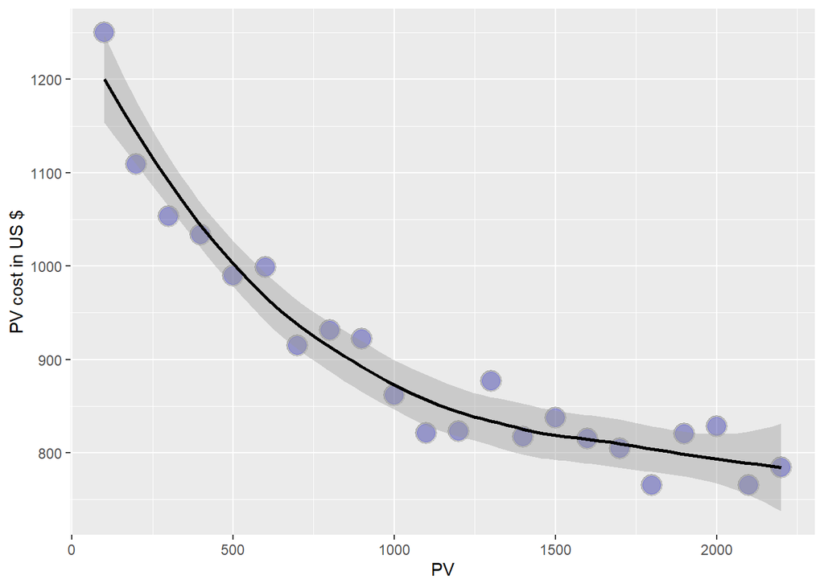

```r
h=ggplot(Mydata,aes(x=number_of_solar_panels,y=Mydata$manufacturing_cost))
h=h+xlab("PV")
h=h+ylab("PV cost in US $")
h=h+geom_point(size=6,colour="black",alpha=0.2)
h=h+geom_point(size=5,colour="blue",alpha=0.2)
h=h+geom_smooth(method="loess",colour="black")
h
```

[figure not shown]

```r
Mydata=Mydata %>% mutate(LogPV=log10(number_of_solar_panels))
Mydata=Mydata %>% mutate(LogCost=log10(manufacturing_cost))
g=ggplot(Mydata,aes(x=number_of_solar_panels,y=Mydata$manufacturing_cost))
g=g+xlab("LogPV")
g=g+ylab("LogCost")
g=g+geom_point(size=6,colour="black",alpha=0.2)
g=g+geom_point(size=5,colour="blue",alpha=0.2)
g=g+geom_smooth(method="lm",colour="black")
g
```

## Question 2

Once you have answered the above questions, conduct a linear regression with the transformed data use R to estimate the regression model Please interpret the results of the regression analysis! How well does the model explain the data? What is the learning rate that applies in this case?

```r
fit=with(Mydata,lm(LogCost~LogPV))
summary(fit)
```

```
##
## Call:
## lm(formula = LogCost ~ LogPV)
##
## Residuals:
##       Min        1Q    Median        3Q       Max
## -0.023675 -0.008668 -0.001944  0.009214  0.020800
##
## Coefficients:
##              Estimate Std. Error t value Pr(>|t|)
## (Intercept)  3.409353   0.023629  144.28  < 2e-16 ***
## LogPV       -0.154991   0.007936  -19.53  1.7e-14 ***
## ---
## Signif. codes:  0 '***' 0.001 '**' 0.01 '*' 0.05 '.' 0.1 ' ' 1
##
## Residual standard error: 0.01299 on 20 degrees of freedom
## Multiple R-squared:  0.9502, Adjusted R-squared:  0.9477
## F-statistic: 381.4 on 1 and 20 DF,  p-value: 1.701e-14
```

This model seems to fit well our sample. Indeed, since adjusted R2 value (0.9477) is close to 1, we can affirm that the multiplicative learning model applies to our data.  
Regression model equation: LogCost = 3.409 – 0.155 LogPV,  
Before proceeding, there are a couple of ways of interpreting the regression equation:  
First, since we are dealing with a multiplicative relationship, we can interpret the coefficient -0.155 as an elasticity. That means that when PV (the cumulative output) increases by 1%, costs in US $ tend to decrease by approximately 0.155%.  
Second, we can use the regression equation to calculate the learning rate. As stated in the lecture, the experience curve is representative of an empirical law by which each duplication of the accumulated output of a product in a certain period of time decreases is marginal cost with a constant percentage i.e. the learning rate.

### Learning rate

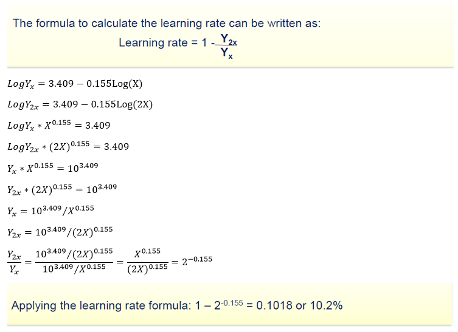

we learnt how we can calculate the learning rate. So by having the coefficients we can calculate it:

```r
Learning_rate=1-2^coef(fit)[2]
Learning_rate
```

```
##     LogPV
## 0.1018618
```

We find that the learning curve rate is 0.1018. In other words, whenever cumulative production doubles, the average cost to produce PVs decreases by about 10.2%.

As mentioned before, the learning rate represents the decrease in manufacturing costs each time the production is doubled. The higher it is, the higher the competitive disadvantage: late industry entrants are penalized. It is more difficult for them to enter the market as early entrants could easily push them out, by decreasing their price, rendering the others to low margins.

## Question 3

Please use the experience curve estimate from the regression model to calculate the expected average manufacturing cost per solar panel for the 400 solar panels that would be produced for Switzerland Hint estimate the average production cost per solar panel for 4700 4800 4900 and 5000 units and compute their mean

Now, we should calculate the mean of the average production cost per solar panel 4,700 to 5,000.

```r
Mydata=Mydata %>% add_row(number_of_solar_panels= seq(2300, 5000, by =100))
Mydata=Mydata %>% mutate(LogPV=log10(number_of_solar_panels))
Mydata=Mydata %>% mutate(PredictedLogCost=predict(fit,newdata=data.frame(LogPV)))
Mydata=Mydata %>% mutate(PredictedCost=10^(PredictedLogCost))
```

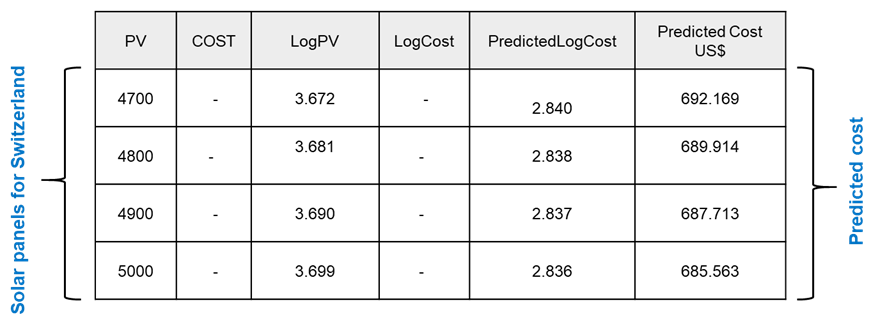

```r
APC=mean(Mydata$PredictedCost[Mydata[,1]<=5000 & Mydata[,1]>=4700])
APC
```

```
## [1] 688.8399
```

## Question 4

Please calculate a 95 confidence interval for the average manufacturing cost per solar panel for the panels produced for Switzerland by using the lower and upper bounds of the confidence interval estimate for the experience parameter You should calculate two extra regression equations for both limits and then calculate the expected average manufacturing cost per solar panel for the 400 solar panels that would be produced for Switzerland as in exercise 3.

The model we have calculated (LogCost regressed on Log_PV) provides us with both a constant value of 3.409 and an unstandardized B coefficient of -0.155.

To calculate a 95% confidence interval for the average manufacturing cost per solar panel, we need to run the following commands:

```r
CI=confint(fit)
CI
```

```
##                  2.5 %     97.5 %
## (Intercept)  3.3600629  3.4586432
## LogPV       -0.1715456 -0.1384356
```

On the table above you can see the two extreme limits i.e. lower bound constant is 3.360 and high bound is 3.459. B unstandardized coefficients are respectively -0.172 and -0.138.

We compute the optimistic scenario, i.e. lower bound costs and the pessimistic one, the upper costs bound. In equations below, the negative scenario estimations are in red and the positive ones are in green.

Upper bound regression model equation: LogCost = 3.459 – 0.138 LogPV  
Lower bound regression model equation: LogCost = 3.360 – 0.172 LogPV

```r
Mydata=Mydata %>% mutate(LogPredictedCost_Lower=Mydata$LogPV*CI[2,1]+CI[1,1])
Mydata=Mydata %>% mutate(LogPredictedCost_Upper=Mydata$LogPV*CI[2,2]+CI[1,2])
Mydata=Mydata %>% mutate(PredictedCost_Lower=10^(LogPredictedCost_Lower))
Mydata=Mydata %>% mutate(PredictedCost_Upper=10^(LogPredictedCost_Upper))

APC_Lower=mean(Mydata$PredictedCost_Lower[Mydata[,1]<=5000 & Mydata[,1]>=4700])
APC_Lower
```

```
## [1] 534.3346
```

```r
APC_Upper=mean(Mydata$PredictedCost_Upper[Mydata[,1]<=5000 & Mydata[,1]>=4700])
APC_Upper
```

```
## [1] 888.0212
```

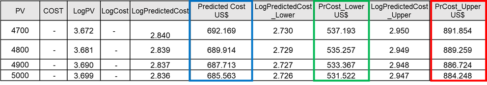

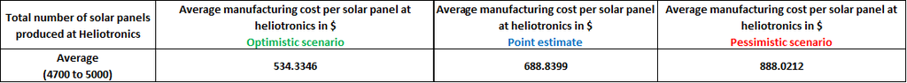

The lower bound estimates is around 534.3346 in average for the 400 panels to be produced; while the upper bound estimates is 888.0212